# MATH9102 Task 1 + 3 Example

Author

Deirdre Lawless

# 1. Introduction

This analysis investigates whether key psychological factors in particular perceived stress, perceived control of internal states, and life satisfaction can be considered to predict an individual’s total optimism score. A secondary aim is to examine whether this relationship varies across different categories of marital status. To address this, a differential-effect model was developed by testing whether the association differs across three marital-status groups: not in a relationship, in a relationship, and married/other.

Two regression models were fitted:

- Baseline Model: Optimism predicted by stress, perceived control, and life satisfaction.
- Comparison Model: Adds marital status.

# 2. Methods

Data were obtained from a psychological well-being survey. Variables were screened for missingness, distributional suitability, and coding accuracy. Marital status was recoded into three groups to ensure adequate sample sizes and interpretability.

Analyses followed a standard multiple linear regression workflow:

- Univariate analysis (normality, central tendency, variance, outliers).
- Bivariate testing (correlations, boxplots).
- Model fitting for Model 1 and Model 2.
- Assumption checks (normality, linearity, homoscedasticity, outliers/influential cases, multicollinearity).
- Interpretation and model comparison using adjusted R², significance, and diagnostic performance.

All analyses were conducted in R.

Using the guidance of Curran, Finch and West (1996) and Field (2025) a continuous variable was treated as approximately normal if the absolute values of standardised skew and kurtosis for the variable fell within +/2 and 99.7% of absolute scores fell within +/- 3.29. Using the guidance of Tabachnick and Fidell (2020) if missing data was less than 5% for any variable and was missing in a random pattern it was omitted from the dataset.

A significance threshold of p < .05 was used throughout.

# 3. Data Preparation and Exploration Results

Prior to model building, all variables were examined for completeness, distributional properties, and suitability for inclusion in multiple linear regression. The dataset consisted of 425 complete cases, with no missing data on the variables used in the models.

Descriptive statistics indicated that all continuous variables demonstrated adequate variability for regression analysis. Optimism scores ranged from 7 to 30 (M = 22.15, SD = 4.40). Perceived stress ranged from 12 to 46 (M = 26.74, SD = 5.84), perceived control ranged from 20 to 88 (M = 60.58, SD = 11.97), and life satisfaction ranged from 5 to 35 (M = 22.44, SD = 6.71).

Marital status was recoded into three conceptually and numerically appropriate groups:

1. not in a relationship (SINGLE, SEPARATED, DIVORCED),
2. in a relationship (STEADY RELATIONSHIP, LIVING WITH PARTNER), and
3. married/other (MARRIED FIRST TIME, REMARRIED, WIDOWED).

The distribution across these group (31.5%, 16.7%, and 51.8%, respectively), is adequate for modelling.

Pearson’s correlations were used to examine associations between psychological variables and optimism. Optimism was significantly negatively correlated with perceived stress, r = –.47, p < .001, and significantly positively correlated with both perceived control, r = .52, p < .001, and life satisfaction, r = .50, p < .001. These results are consistent with established theoretical accounts linking optimism with lower stress and more favourable psychological profiles.

A boxplot examining optimism scores across marital-status groups showed only modest differences in central tendency (see Appendix 1), suggesting that while marital status may not be strongly associated with optimism at the mean level, it may still operate as a moderator, justifying its inclusion in the comparison model.

# 4. Regression Model — Baseline Model

## 4.1 Psyhcological Predictors Only

Perceived stress was a statistically significant negative predictor of optimism (b = –0.09, SE = 0.04, t(421) = –2.37, p = .018) indicating that higher levels of perceived stress were associated with lower optimism.

Perceived control was a statistically significant positive predictor (b = 0.12, SE = 0.02, t(421) = 6.91, p < .001), suggesting that individuals with greater perceived control reported higher optimism.

Life satisfaction was also a statistically significant predictor of optimism (b = 0.21, SE = 0.03, t(421) = 7.20, p < .001), indicating that higher life satisfaction was associated with higher optimism.

Standardized coefficients suggested that perceived control (β = .33) and life satisfaction (β = .32) were stronger predictors than perceived stress (β = –.12).

## 4.2 Assumption Checks

Regression assumptions were evaluated to ensure the appropriateness of the model (see Appendix 2 for plots and test output).

A Kolmogorov–Smirnov-type test indicated no significant deviation of residuals from normality, p = .554. Visual inspection of Q–Q plots showed minor tail deviations, but overall residuals appeared approximately normal.

Component-plus-residual plots revealed no departures from linearity for any predictor (all ps > .18). Standardized residuals ranged from –3.31 to 3.26. No cases were identified as influential according to Bonferroni-adjusted criteria.

Overall, the model met all major regression assumptions aside from minor heteroscedasticity.

## 4.3 Summary of BaselineModel

Individuals with higher life satisfaction and stronger internal control beliefs tended to report greater optimism, whereas those experiencing greater stress reported lower levels of optimism. Together, these psychological variables formed a robust model of optimism.

Aside from minor heteroscedasticity, the baseline model met all key assumptions and provided a statistically sound basis for interpretation.

# 5. Comparison Model — Differential Effect Included

## 5.1 Differential Effect by Marital Status

A second regression model was estimated to examine whether marital status contributed additional explanatory power beyond the psychological predictors included in the baseline model. Marital status was entered as a three-level categorical predictor (not in a relationship, in a relationship, married/other), with “not in a relationship” serving as the reference group.

The model was statistically significant, F(5, 419) = 52.37, p < .001, and explained 38.5% of the variance in optimism (adjusted R² = .377). Perceived stress was a statistically significant negative predictor (b = –0.09, SE = 0.04, p = .021). Perceived control was a strong positive predictor (b = 0.12, SE = 0.02, p < .001). Life satisfaction can also be considered to significantly predict optimism (b = 0.21, SE = 0.03, p < .001).

In contrast, marital status did not significantly predict optimism:

- In-relationship vs. not in relationship: b = 0.18, p = .736
- Married/other vs. not in relationship: b = 0.18, p = .644

These findings indicate that average optimism levels did not differ across marital-status categories after accounting for stress, perceived control, and life satisfaction.

This model shows that marital status does not significantly contribute to predicting optimism when psychological factors are already included.

## 5.2 Assumption Checks Model 2

Regression assumptions were evaluated (see Appendix 3 for plots and test output).

Residuals did not significantly deviate from normality, p = .552. Q–Q plots showed good alignment with the theoretical distribution. No cases exceeded Bonferroni-adjusted thresholds for studentized residuals(Standardized residuals: range = –3.32 to 3.32.)

The model met all major regression assumptions aside from minor heteroscedasticity. The model is suitable for interpretation.

## 5.3 Summary of Model 2

Marital status included as a predictor did not independently predict optimism. The psychological variables — particularly perceived control and life satisfaction — were the strongest contributors to optimism. All meaningful explanatory power resides in the psychological predictors, not demographic grouping. This suggests that individuals’ subjective psychological experiences are more important determinants of optimism than their marital status.

The inclusion of marital status neither violated model assumptions nor introduced substantial instability.

# 6. Model Comparison

Including marital status did not improve prediction accuracy compared to the baseline and did no demonstrate a significant differential effect for different marital status. Both models were significant overall, but psychological variables consistently explained optimism, whereas marital status contributions were negligible.

The baseline model is therefore the more parsimonious and theoretically meaningful model. Psychological factors —stress, perceived control, and life satisfaction — are robust predictors of optimism. Marital status does not meaningfully improve prediction nor account for unique variance in optimism beyond these psychological variables. The baseline model is therefore preferred for both explanatory clarity and statistical efficiency.

| Statistic | Baseline Model | Model 2 | Interpretation |
| --- | --- | --- | --- |
| Adjusted R² | .380 | .377 | Model 2 explains no additional variance |
| Predictors added | — | Marital status | No significant effects |
| F-statistic | 87.57*** | 52.37*** | Both highly significant |
| Conclusion | Better | Worse (less parsimonious) | Baseline Model preferred |

**Table 1: Comparison of Baseline and Comparison Model Fit Statistics**

# 7. Summary

The present analysis examined whether key psychological factors — perceived stress, perceived control, and life satisfaction — could be considered meaningful predictors of optimism, and whether marital status contributed additional explanatory value. Initial data screening confirmed that all variables met the requirements for inclusion in multiple linear regression, with acceptable distributional properties and no problematic outliers. Correlational analyses demonstrated theoretically consistent associations between the psychological variables and optimism.

The baseline model, which included only the psychological predictors, was statistically significant and accounted for 38% of the variance in optimism. Perceived control and life satisfaction were strong positive predictors, whereas perceived stress negatively predicted optimism. Assumption checks indicated that the model was robust, with only minor heteroscedasticity observed.

The comparison model added marital status as a three-level categorical predictor. Although the model remained statistically significant, marital status did not meaningfully improve prediction of optimism, nor did it independently predict optimism. The adjusted R² remained essentially unchanged, indicating that marital status contributes little explanatory power beyond the psychological factors.

Across both models, psychological variables emerged as the strongest and most consistent predictors of optimism. Marital status appears to have limited relevance once these psychological experiences are taken into account. Taken together, these findings highlight the importance of subjective psychological states—rather than demographic categories—in shaping individual levels of optimism.

# References

Curran, P. J., West, S. G., & Finch, J. F. (1996). The robustness of test statistics to nonnormality and specification error in confirmatory factor analysis. Psychological Methods, 1(1), 16–29. https://doi.org/10.1037/1082-989X.1.1.16

Cohen, J. (1988). Statistical power analysis for the behavioral sciences (2nd ed.). Lawrence Erlbaum Associates.

Field, A., Miles, J., & Field, Z. (2025). Discovering statistics using R and RStudio (2nd ed.). Sage.

Tabachnick, B. G., & Fidell, L. S. (2020). Using multivariate statistics (7th ed.). Pearson.

# Appendix 1 - Plots, Descriptives and Exploratory Tests

## Continuous Data Descriptives and Plots

```
     nbr.val     nbr.null       nbr.na          min          max        range
 425.0000000    0.0000000    0.0000000    7.0000000   30.0000000   23.0000000
         sum       median         mean      SE.mean CI.mean.0.95          var
9412.0000000   22.0000000   22.1458824    0.2136174    0.4198809   19.3937625
     std.dev     coef.var
   4.4038350    0.1988557
```

```
     nbr.val     nbr.null       nbr.na          min          max        range
4.250000e+02 0.000000e+00 0.000000e+00 1.200000e+01 4.600000e+01 3.400000e+01
         sum       median         mean      SE.mean CI.mean.0.95          var
1.136400e+04 2.600000e+01 2.673882e+01 2.833133e-01 5.568734e-01 3.411323e+01
     std.dev     coef.var
5.840653e+00 2.184334e-01
```

```
     nbr.val     nbr.null       nbr.na          min          max        range
4.250000e+02 0.000000e+00 0.000000e+00 2.000000e+01 8.800000e+01 6.800000e+01
         sum       median         mean      SE.mean CI.mean.0.95          var
2.574500e+04 6.200000e+01 6.057647e+01 5.805379e-01 1.141091e+00 1.432353e+02
     std.dev     coef.var
1.196809e+01 1.975700e-01
```

```
     nbr.val     nbr.null       nbr.na          min          max        range
 425.0000000    0.0000000    0.0000000    5.0000000   35.0000000   30.0000000
         sum       median         mean      SE.mean CI.mean.0.95          var
9535.0000000   23.0000000   22.4352941    0.3255531    0.6398990   45.0435627
     std.dev     coef.var
   6.7114501    0.2991470
```

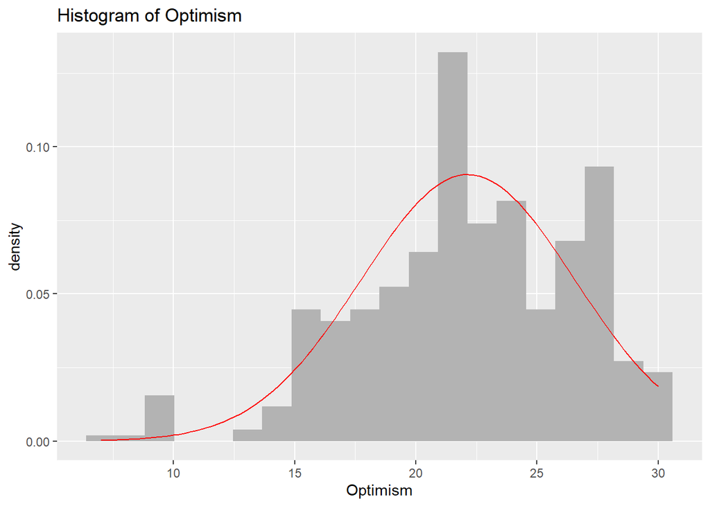

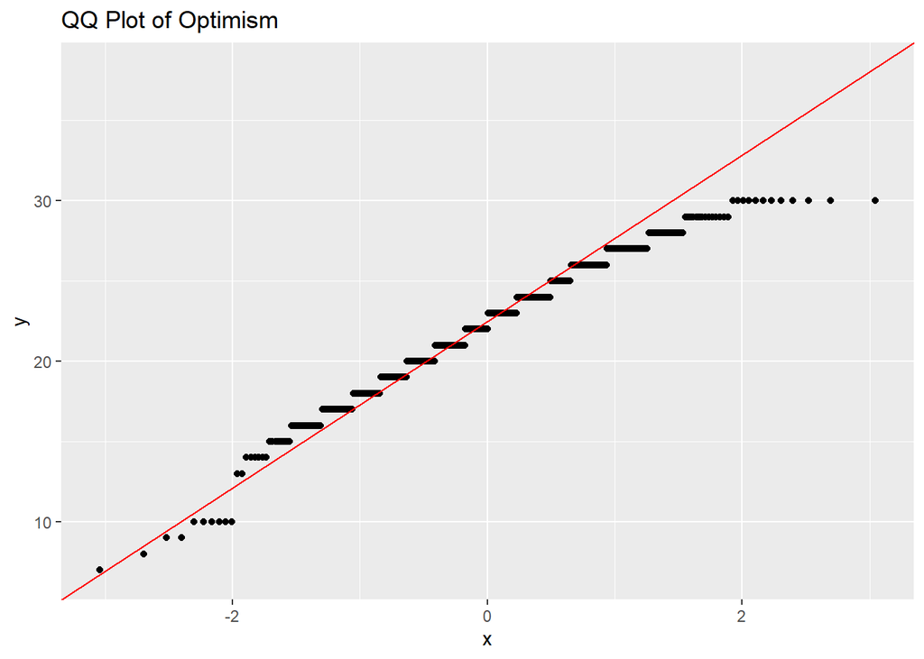

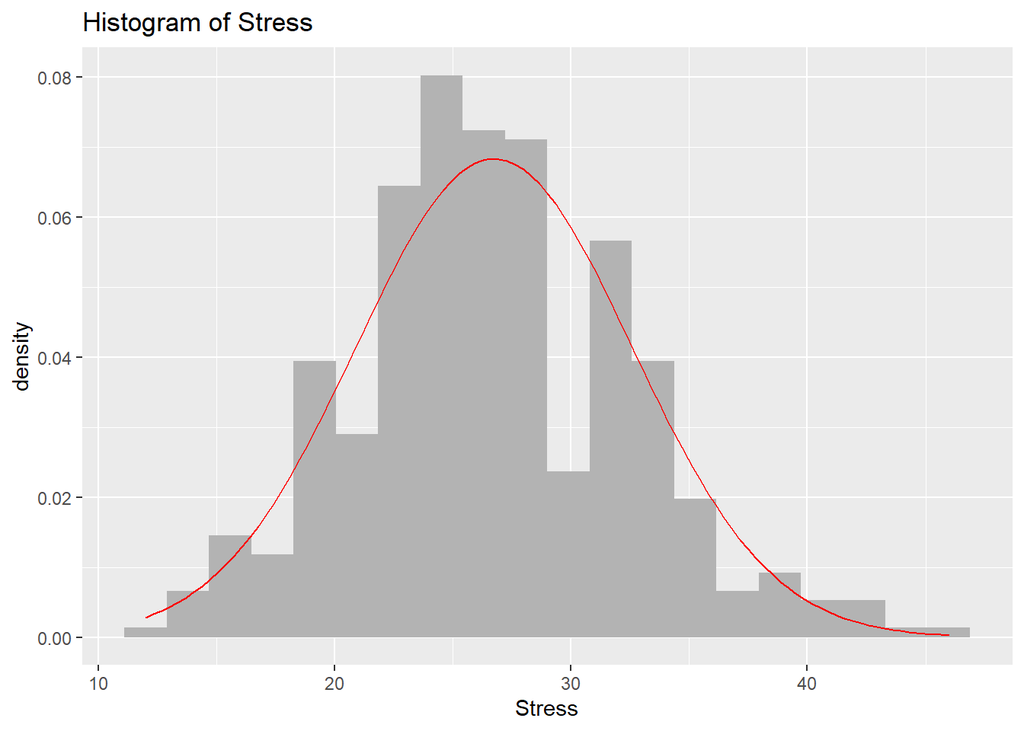

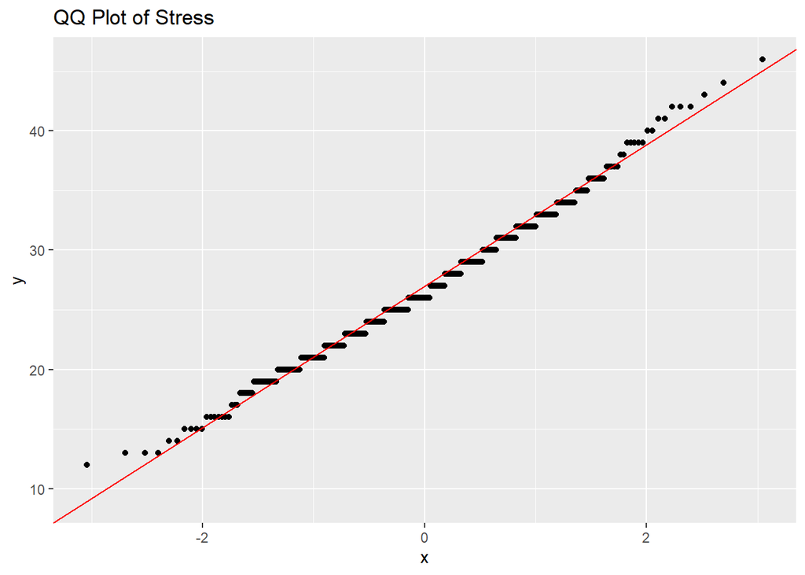

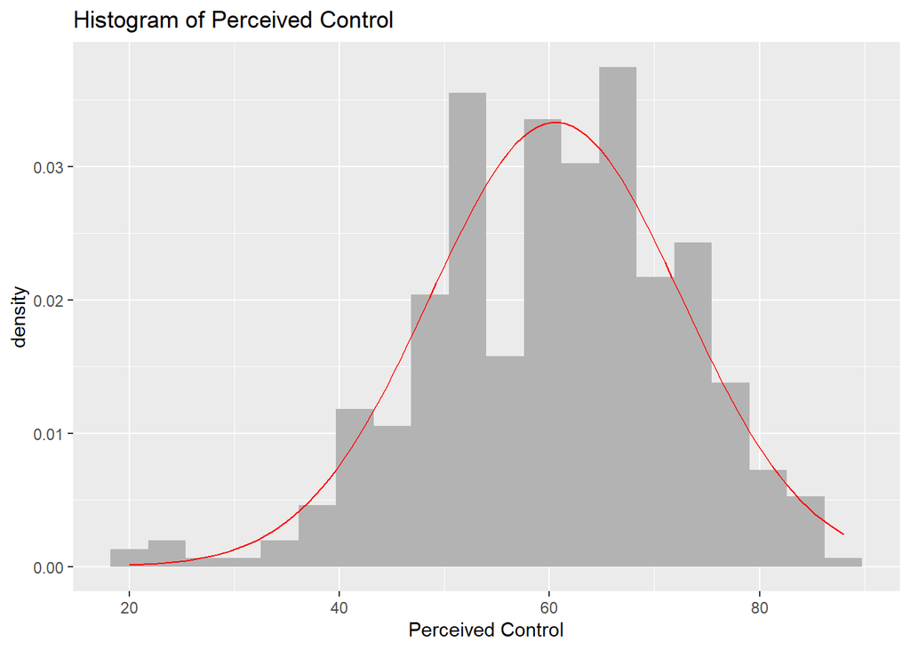

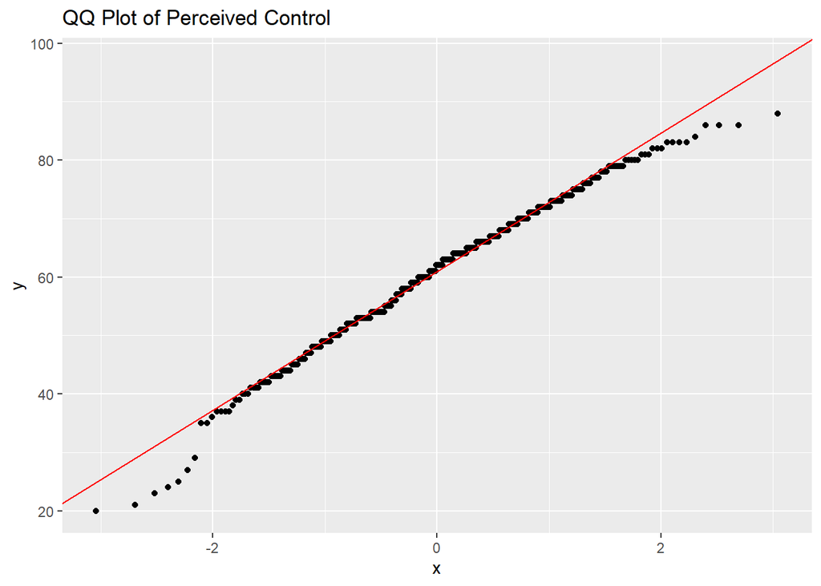

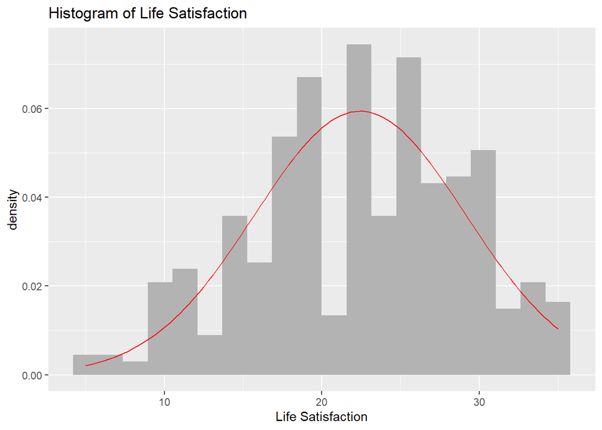

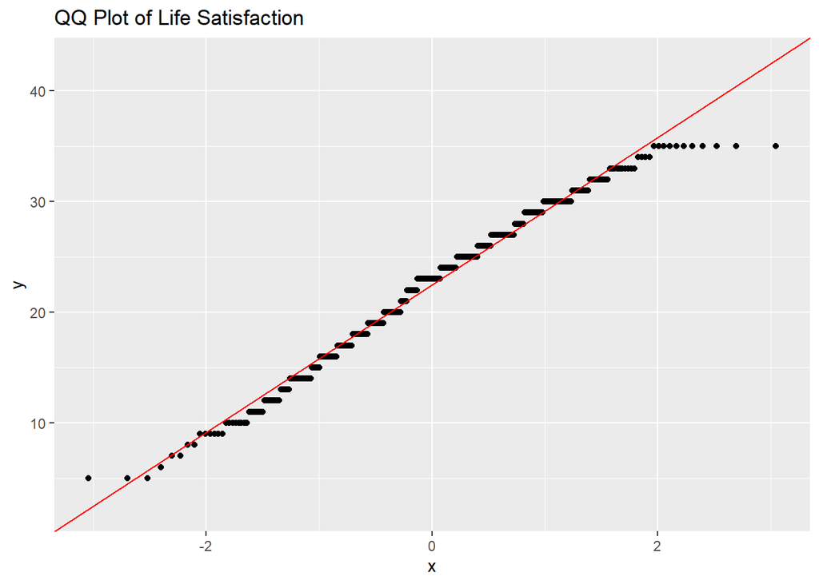

## Categorical Data and Plots

```
not_in_relationship     in_relationship       married_other
                134                  71                 220
```

```
not_in_relationship     in_relationship       married_other
          0.3152941           0.1670588           0.5176471
```

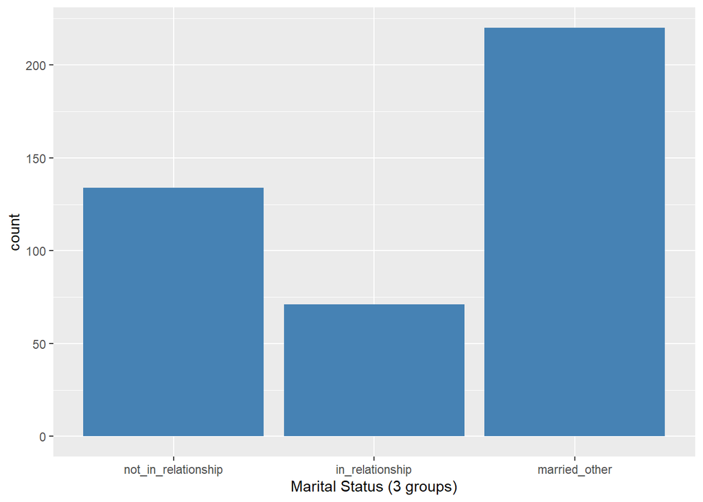

## Exploratory testing

```
    Pearson's product-moment correlation

data:  sdata$tpstress and sdata$toptim
t = -10.886, df = 423, p-value < 2.2e-16
alternative hypothesis: true correlation is not equal to 0
95 percent confidence interval:
 -0.5389449 -0.3900410
sample estimates:
       cor
-0.4678059
```

```
    Pearson's product-moment correlation

data:  sdata$tpcoiss and sdata$toptim
t = 12.363, df = 423, p-value < 2.2e-16
alternative hypothesis: true correlation is not equal to 0
95 percent confidence interval:
 0.4417270 0.5818093
sample estimates:
      cor
0.5152006
```

```
    Pearson's product-moment correlation

data:  sdata$tlifesat and sdata$toptim
t = 11.892, df = 423, p-value < 2.2e-16
alternative hypothesis: true correlation is not equal to 0
95 percent confidence interval:
 0.4257169 0.5686145
sample estimates:
      cor
0.5005677
```

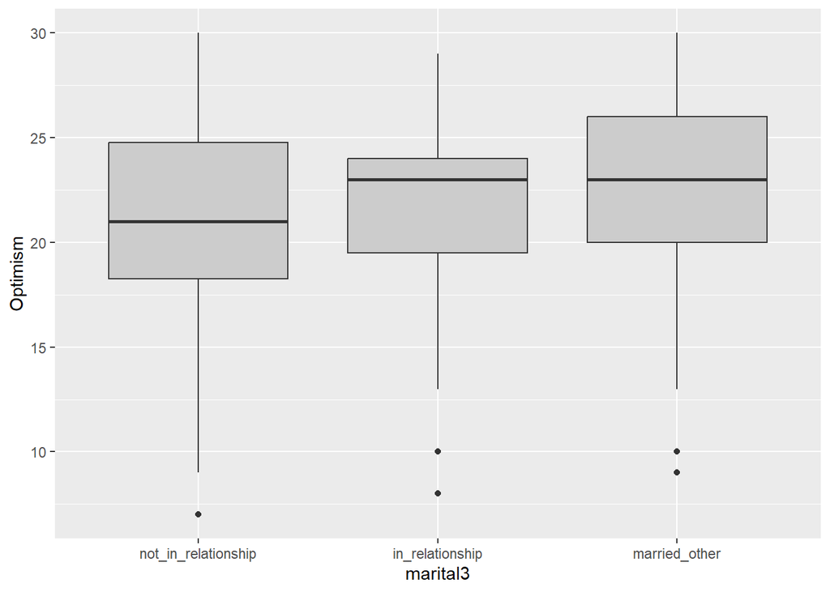

# Appendix 2 - Baseline Model

## Model 1: Psyhcological Predictors Only

```
Call:
lm(formula = toptim ~ tpstress + tpcoiss + tlifesat, data = sdata)

Residuals:
     Min       1Q   Median       3Q      Max
-11.4517  -2.3372   0.3153   2.2934  11.1861

Coefficients:
            Estimate Std. Error t value Pr(>|t|)
(Intercept) 12.57717    1.99670   6.299 7.55e-10 ***
tpstress    -0.09033    0.03811  -2.370   0.0182 *
tpcoiss      0.12022    0.01740   6.908 1.82e-11 ***
tlifesat     0.20957    0.02911   7.198 2.82e-12 ***
---
Signif. codes:  0 '***' 0.001 '**' 0.01 '*' 0.05 '.' 0.1 ' ' 1

Residual standard error: 3.468 on 421 degrees of freedom
Multiple R-squared:  0.3842,    Adjusted R-squared:  0.3799
F-statistic: 87.57 on 3 and 421 DF,  p-value: < 2.2e-16
```

```
Analysis of Variance Table

Response: toptim
           Df Sum Sq Mean Sq F value    Pr(>F)
tpstress    1 1799.5 1799.53 149.624 < 2.2e-16 ***
tpcoiss     1  736.9  736.87  61.268 4.073e-14 ***
tlifesat    1  623.2  623.18  51.815 2.822e-12 ***
Residuals 421 5063.4   12.03
---
Signif. codes:  0 '***' 0.001 '**' 0.01 '*' 0.05 '.' 0.1 ' ' 1
```

```
=================================================
                         Dependent variable:
                    -----------------------------
                               toptim
-------------------------------------------------
tpstress                       -0.090*
                               (0.038)

tpcoiss                       0.120***
                               (0.017)

tlifesat                      0.210***
                               (0.029)

Constant                      12.577***
                               (1.997)

-------------------------------------------------
Observations                     425
R2                              0.384
Adjusted R2                     0.380
Residual Std. Error       3.468 (df = 421)
F Statistic            87.569*** (df = 3; 421)
=================================================
Note:               *p<0.05; **p<0.01; ***p<0.001
```

```
Call:
lm(formula = toptim ~ tpstress + tpcoiss + tlifesat, data = sdata)

Standardized Coefficients::
(Intercept)    tpstress     tpcoiss    tlifesat
         NA  -0.1198043   0.3267052   0.3193892
```

## Assumption Checks — Model 1

### Non-zero variance

```
   toptim  tpstress   tpcoiss  tlifesat
 19.39376  34.11323 143.23529  45.04356
```

### Normality of residuals

```
OK: residuals appear as normally distributed (p = 0.554).
```

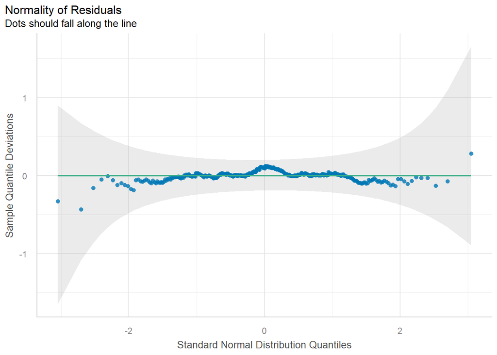

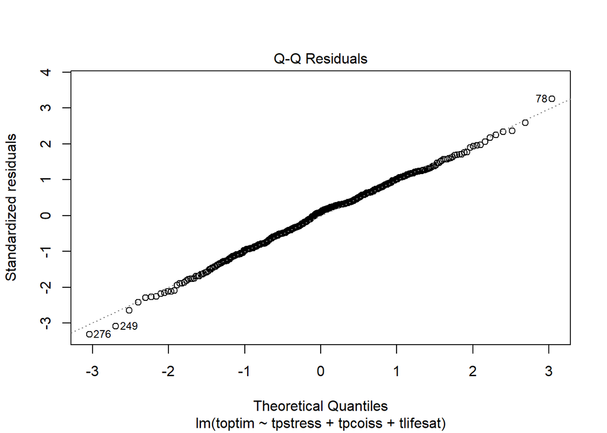

### Standardised Residuals + Outliers

```
[1] 3.259806
```

```
[1] -3.314512
```

```
No Studentized residuals with Bonferroni p < 0.05
Largest |rstudent|:
     rstudent unadjusted p-value Bonferroni p
276 -3.354633         0.00086689      0.36843
```

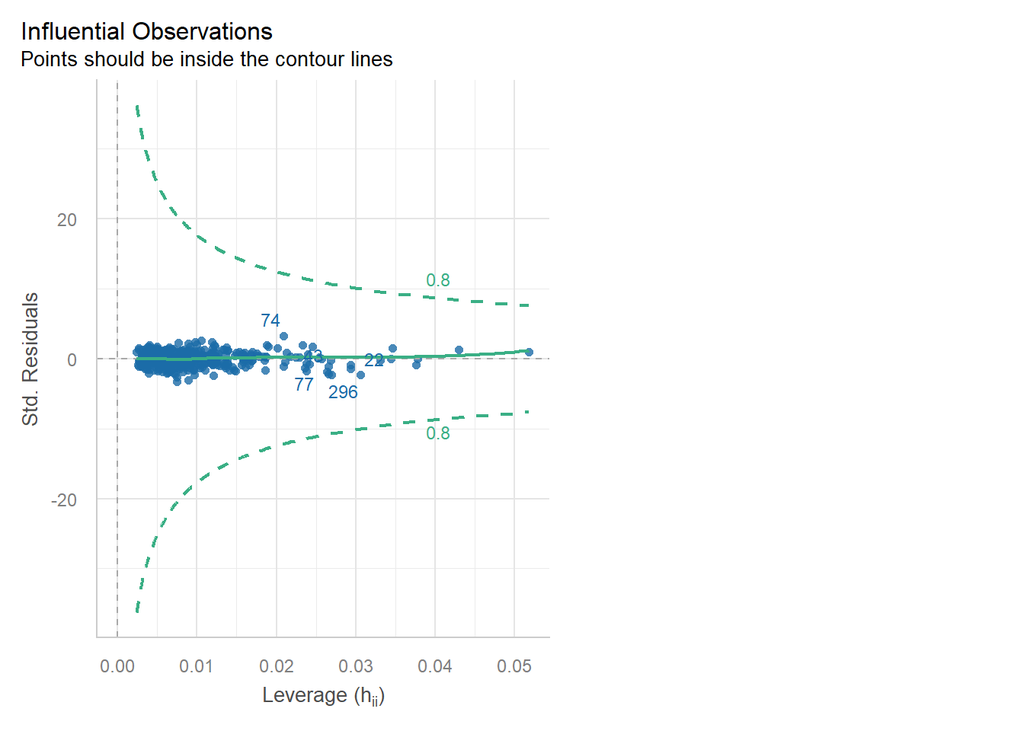

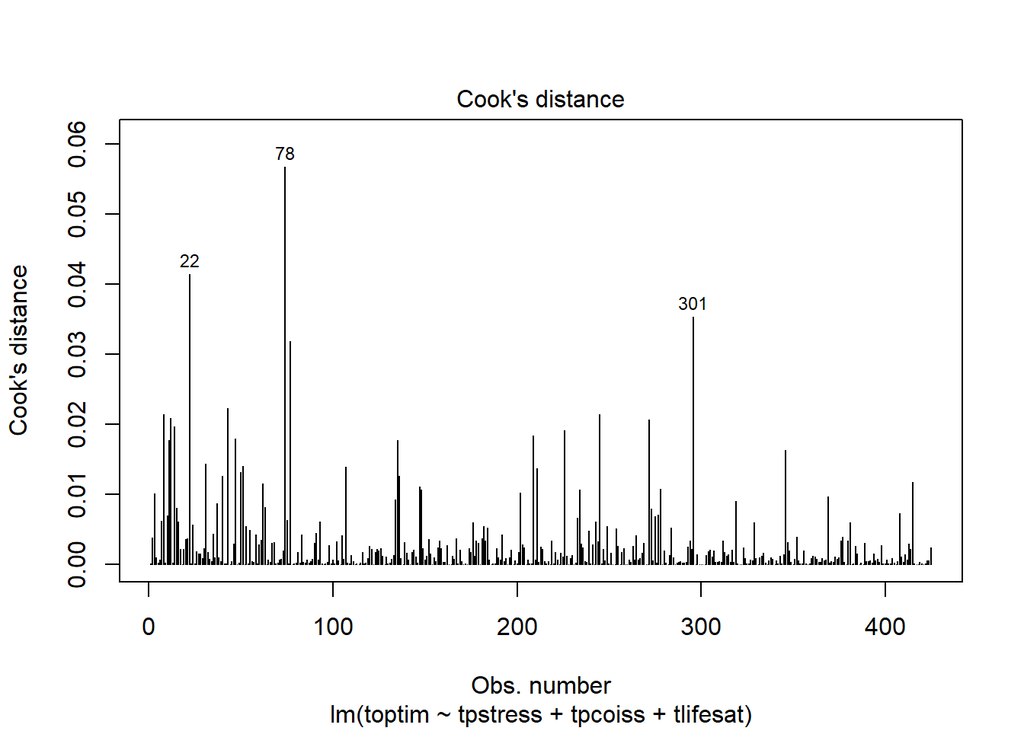

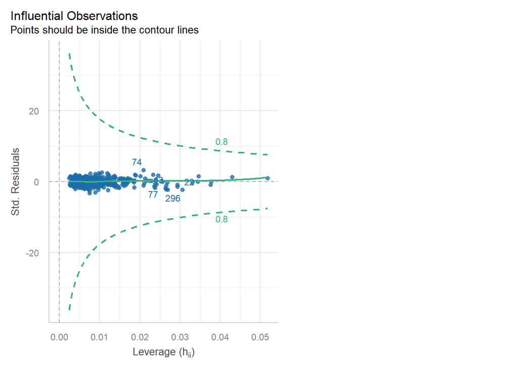

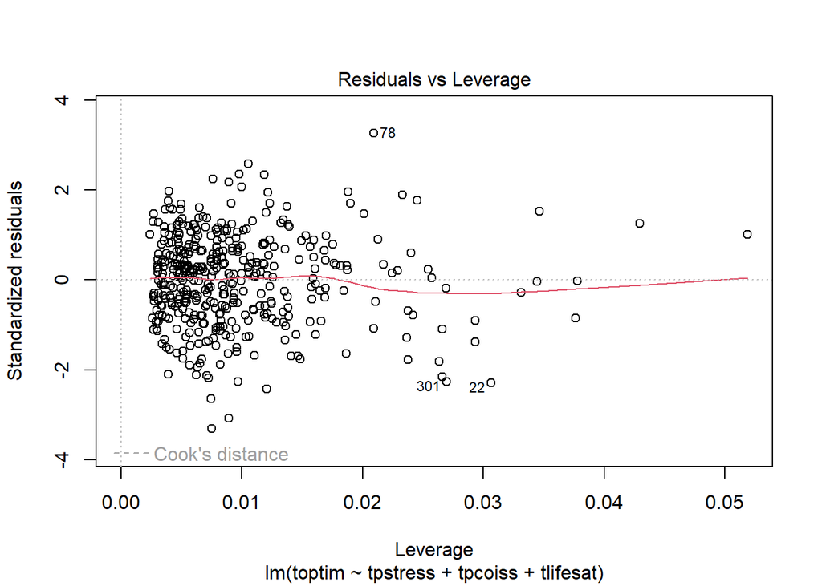

### Homcedasticity

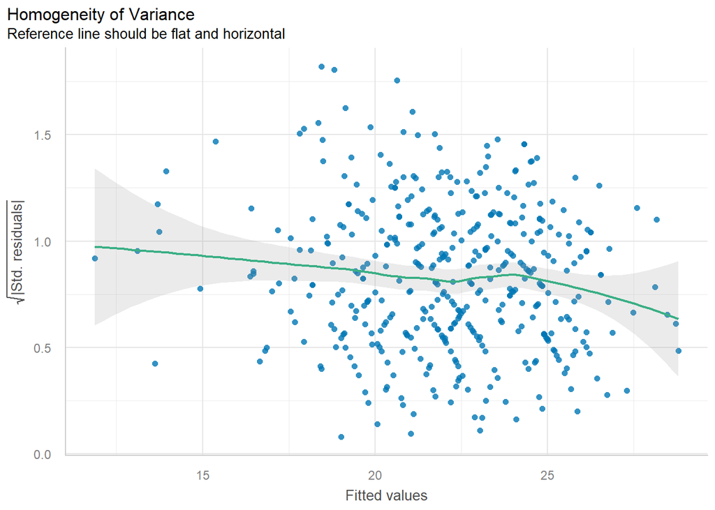

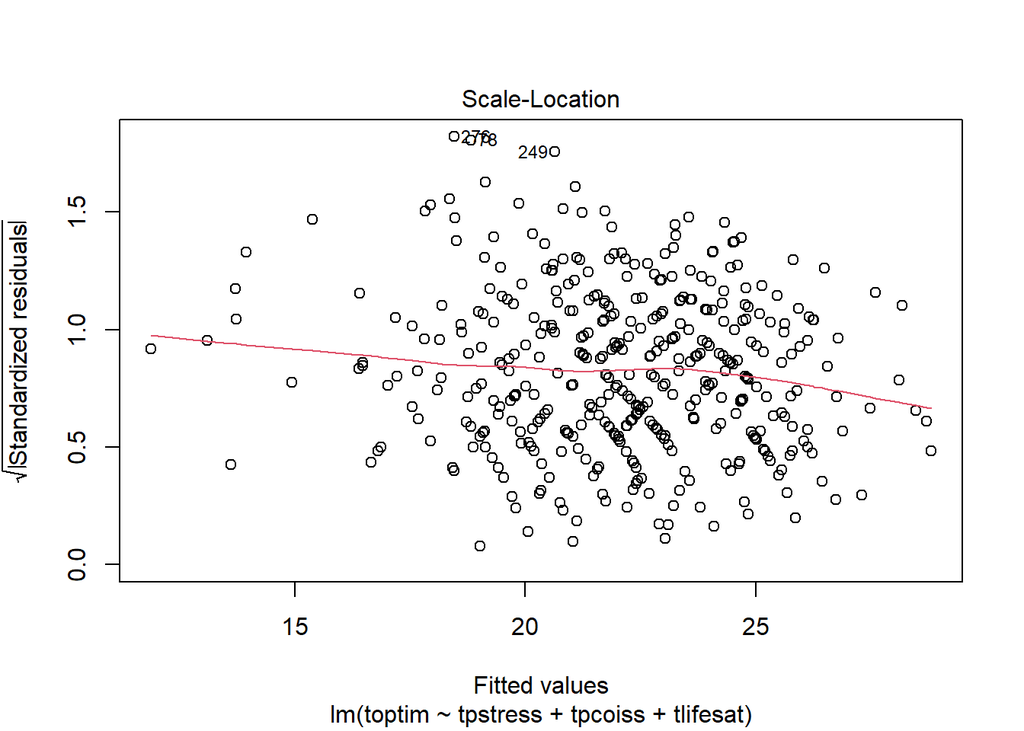

### Linearity

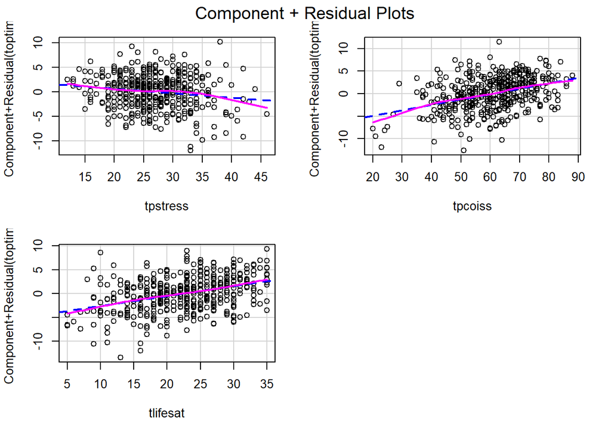

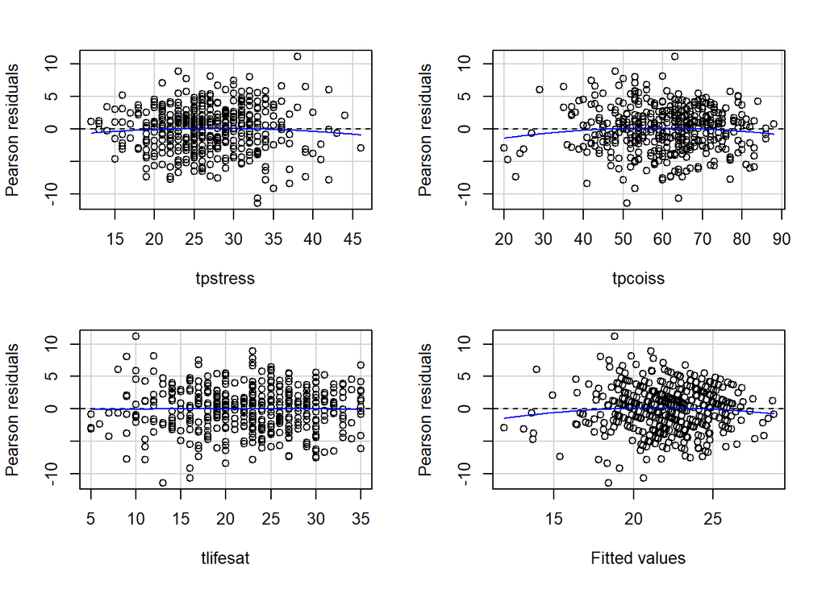

```
           Test stat Pr(>|Test stat|)
tpstress     -0.8735           0.3829
tpcoiss      -1.3321           0.1836
tlifesat     -0.1262           0.8996
Tukey test   -1.1494           0.2504
```

### MultiColinearity

```
# Check for Multicollinearity

Low Correlation

     Term  VIF   VIF 95% CI adj. VIF Tolerance Tolerance 95% CI
 tpstress 1.75 [1.55, 2.02]     1.32      0.57     [0.49, 0.65]
  tpcoiss 1.53 [1.37, 1.76]     1.24      0.65     [0.57, 0.73]
 tlifesat 1.35 [1.22, 1.55]     1.16      0.74     [0.65, 0.82]
```

### Combined Residual Plots

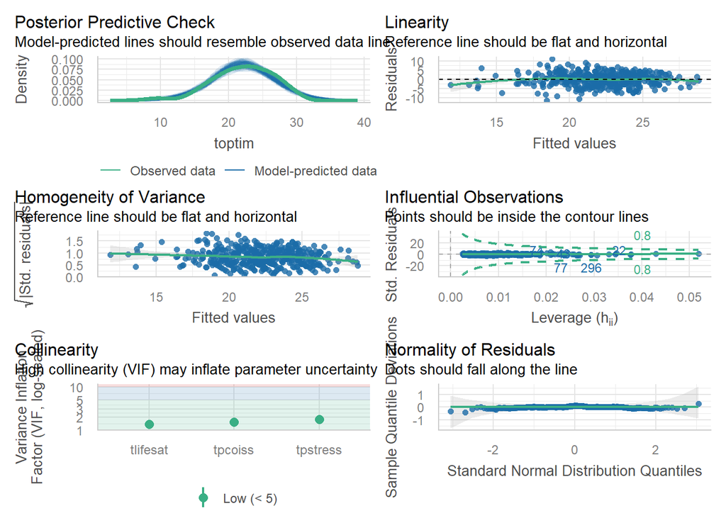

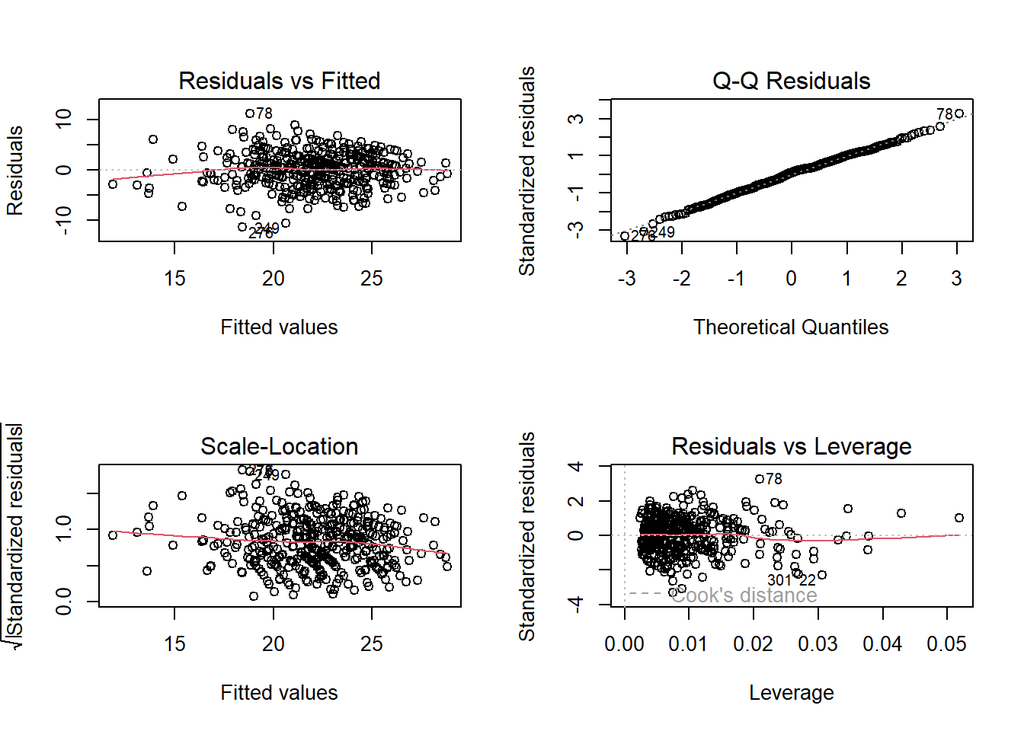

# Appendix 3 - Comparison Model — Differential Effect Included

```
Call:
lm(formula = toptim ~ tpstress + tpcoiss + tlifesat + marital3,
    data = sdata)

Residuals:
    Min      1Q  Median      3Q     Max
-11.354  -2.296   0.308   2.311  11.070

Coefficients:
                        Estimate Std. Error t value Pr(>|t|)
(Intercept)             12.41175    2.03352   6.104 2.36e-09 ***
tpstress                -0.08895    0.03831  -2.322   0.0207 *
tpcoiss                  0.12145    0.01775   6.841 2.80e-11 ***
tlifesat                 0.20645    0.02989   6.906 1.85e-11 ***
marital3in_relationship  0.17661    0.52393   0.337   0.7362
marital3married_other    0.18238    0.39462   0.462   0.6442
---
Signif. codes:  0 '***' 0.001 '**' 0.01 '*' 0.05 '.' 0.1 ' ' 1

Residual standard error: 3.475 on 419 degrees of freedom
Multiple R-squared:  0.3846,    Adjusted R-squared:  0.3772
F-statistic: 52.37 on 5 and 419 DF,  p-value: < 2.2e-16
```

```
Analysis of Variance Table

Response: toptim
           Df Sum Sq Mean Sq  F value    Pr(>F)
tpstress    1 1799.5 1799.53 148.9954 < 2.2e-16 ***
tpcoiss     1  736.9  736.87  61.0108 4.607e-14 ***
tlifesat    1  623.2  623.18  51.5974 3.136e-12 ***
marital3    2    2.8    1.39   0.1153    0.8911
Residuals 419 5060.6   12.08
---
Signif. codes:  0 '***' 0.001 '**' 0.01 '*' 0.05 '.' 0.1 ' ' 1
```

```
=====================================================
                             Dependent variable:
                        -----------------------------
                                   toptim
-----------------------------------------------------
tpstress                           -0.089*
                                   (0.038)

tpcoiss                           0.121***
                                   (0.018)

tlifesat                          0.206***
                                   (0.030)

marital3in_relationship             0.177
                                   (0.524)

marital3married_other               0.182
                                   (0.395)

Constant                          12.412***
                                   (2.034)

-----------------------------------------------------
Observations                         425
R2                                  0.385
Adjusted R2                         0.377
Residual Std. Error           3.475 (df = 419)
F Statistic                52.367*** (df = 5; 419)
=====================================================
Note:                   *p<0.05; **p<0.01; ***p<0.001
```

```
Call:
lm(formula = toptim ~ tpstress + tpcoiss + tlifesat + marital3,
    data = sdata)

Standardized Coefficients::
            (Intercept)                tpstress                 tpcoiss
                     NA             -0.11796831              0.33005128
               tlifesat marital3in_relationship   marital3married_other
             0.31462773              0.01497705              0.02071851
```

## Assumption Checks — Model 2

```
OK: residuals appear as normally distributed (p = 0.552).
```

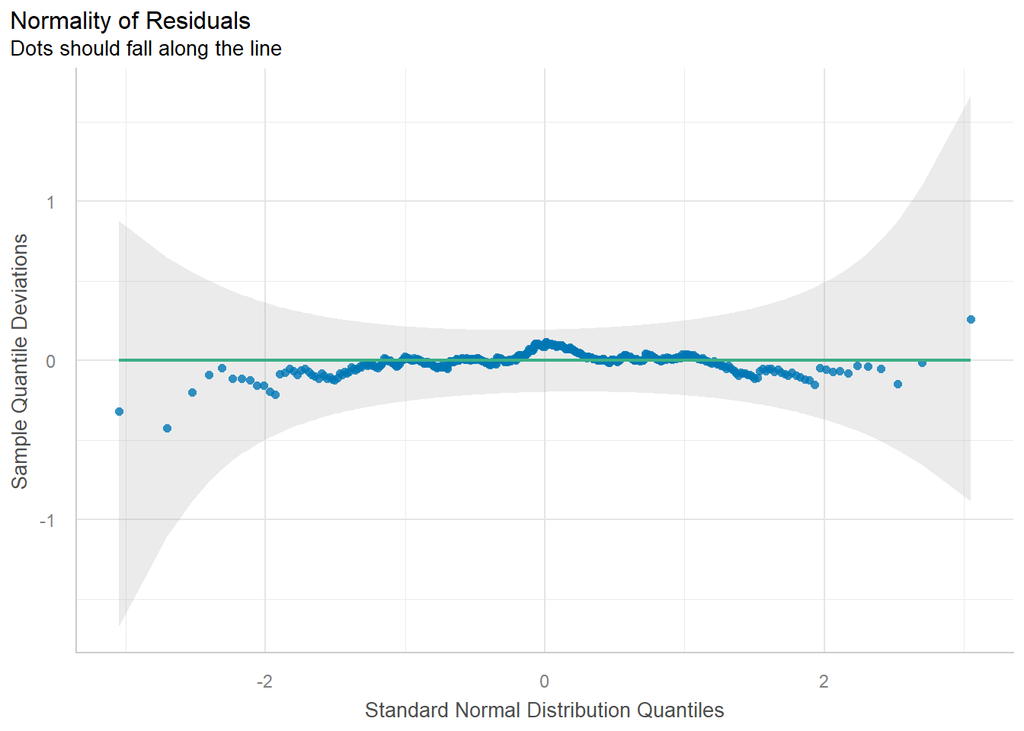

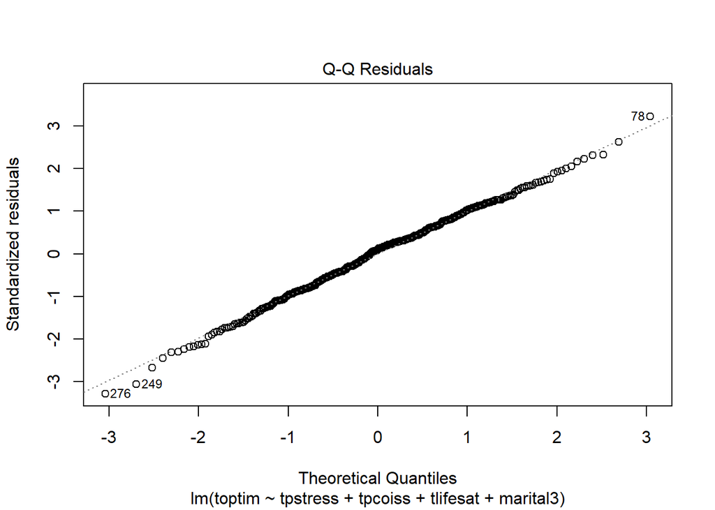

```
No Studentized residuals with Bonferroni p < 0.05
Largest |rstudent|:
     rstudent unadjusted p-value Bonferroni p
276 -3.324313         0.00096451      0.40992
```

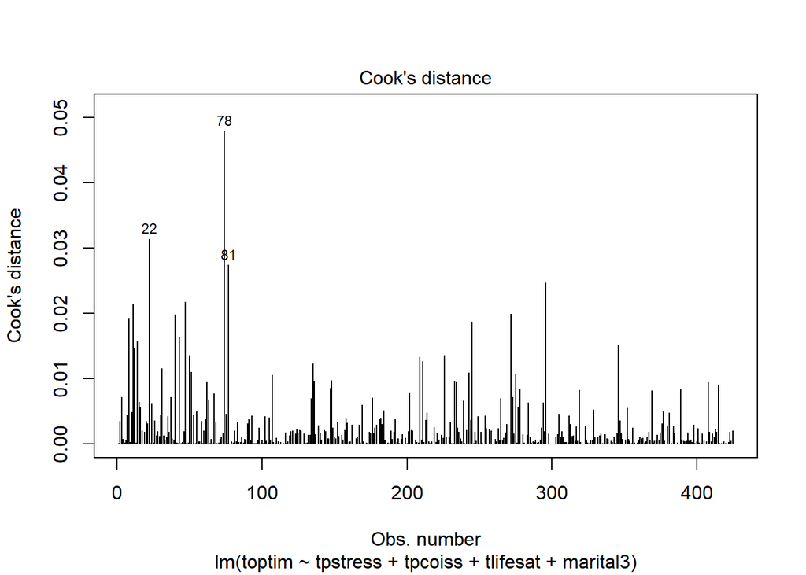

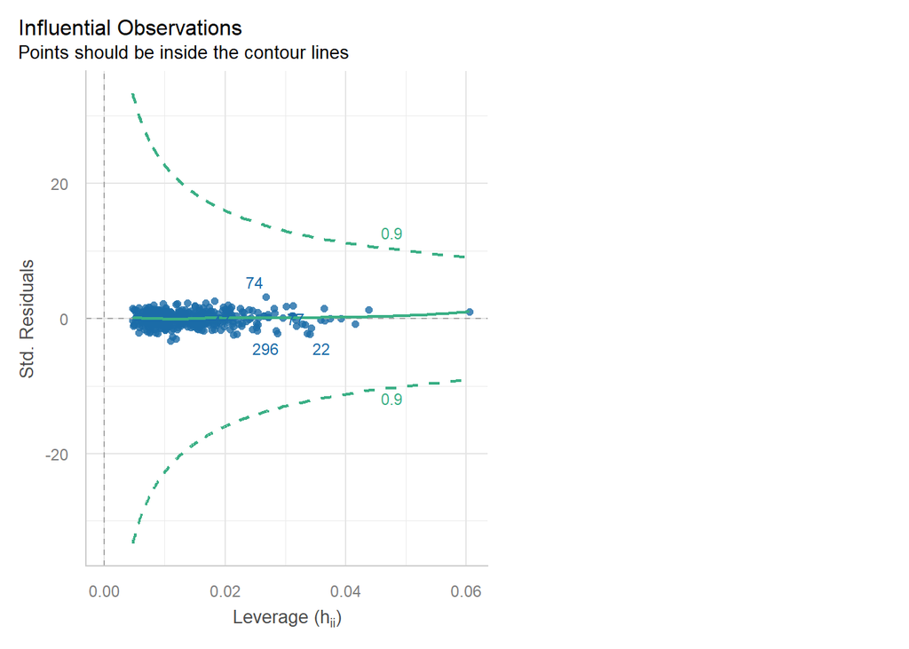

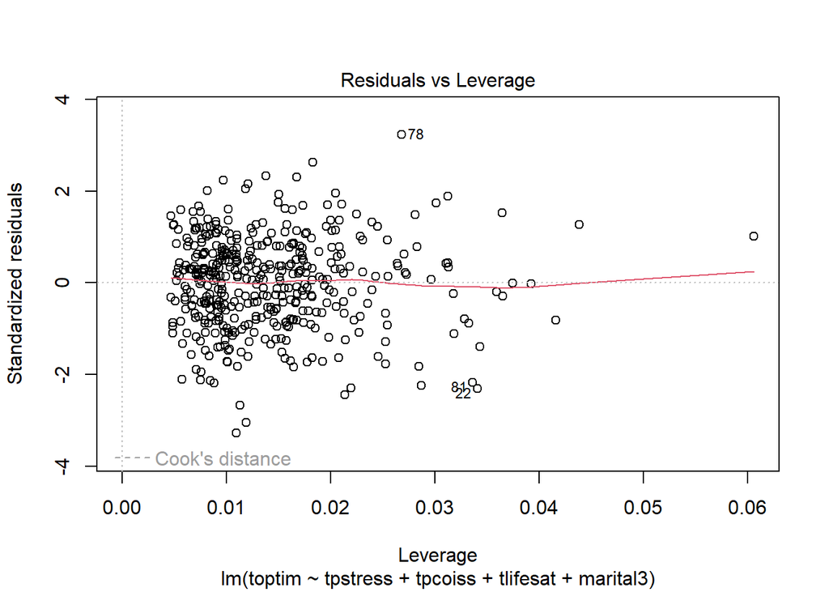

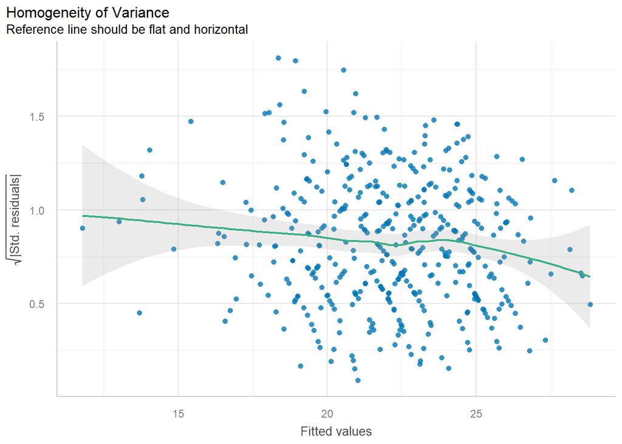

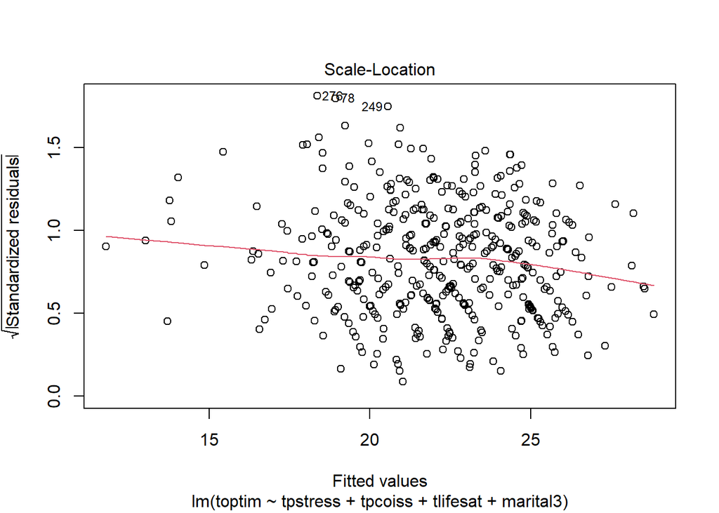

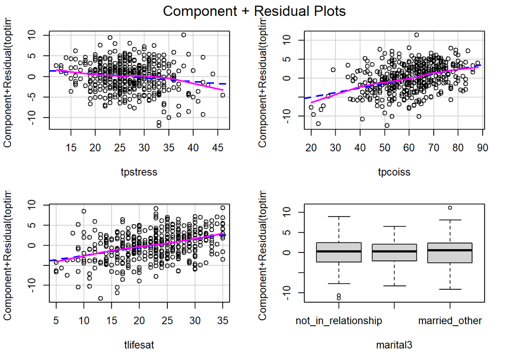